# Math 300 NTI Lesson 6

group_by, mutate, and arrange

Professor Bradley Warner

June, 2022

## Objectives

1. Use the `group_by()` function to create aggregated data frames to use with other functions, in particular `summarize()`, to explore, explain, and visualize.
2. Use the `mutate()` function to create new variables in a data frame in order to explore, explain, and visualize.
3. Use the `arrange()` function to sort data frames to explore, explain, and visualize.

## Reading

[Chapter 3.4 - 3.6](https://moderndive.com/3-wrangling.html#groupby)

## Lesson

Remember that you will be running this more like a lab than a lecture. You want them using `R` and answering questions. Have them open the notes rmd and work through it together.

Work through the learning checks LC3.5 - LC3.12.

- We changed the scaffolded code method. We have `eval=FALSE` so that `R` does not try to evaluate the code chunk. They have to remove this and then complete the code.
- It is important to note that the `group_by()` function doesn’t change data frames by itself. Rather it changes the meta-data, or data about the data, specifically the grouping structure. It is only after we apply the `summarize()` function that the data frame changes. The book does a good job explaining meta-data.
- The `group_by()` can be used on more than two variables but they must be in the same call to `group_by()`.
- Using `arrange()` is straight forward expect the use of `desc()` within the `arrange()` call to sort in decreasing order.
- As a rough rule of thumb, as long as you are not losing original information that you might need later, it’s acceptable practice to overwrite existing data frames with updated ones.
- LC 3.6 is difficult. Let them explore and wrestle with this question. The warning can be ignored. We will not experiment with the `.groups` option.
- LC 3.12 is more difficult as we combined code. The default use of `geom_boxplot()` works for exploring data but we provided code on how to clean up the x-axis. Discuss this code if you want and have time.
- The use of `kable()` is only to have the output printed in a form that looks good. This is not something we need to present to the students.

### Setup

```r
library(nycflights13)
library(ggplot2)
library(dplyr)
```

### LC 3.5 (Objective 1)

**(LC3.5)** Recall from Chapter 2 when we looked at plots of temperatures by months in NYC. What does the standard deviation column in the `summary_monthly_temp` data frame, which we need to create from the code at the section 3.4, tell us about temperatures in New York City throughout the year?

**Solution**:

```r
# Code from the book
summary_temp_by_month <- weather %>%
  group_by(month) %>%
  summarize(
    mean = mean(temp, na.rm = TRUE),
    std_dev = sd(temp, na.rm = TRUE)
  )
```

```r
# Output
summary_temp_by_month
```

```
## # A tibble: 12 x 3
##    month  mean std_dev
##    <int> <dbl>   <dbl>
##  1     1  35.6   10.2
##  2     2  34.3    6.98
##  3     3  39.9    6.25
##  4     4  51.7    8.79
##  5     5  61.8    9.68
##  6     6  72.2    7.55
##  7     7  80.1    7.12
##  8     8  74.5    5.19
##  9     9  67.4    8.47
## 10    10  60.1    8.85
## 11    11  45.0   10.4
## 12    12  38.4    9.98
```

The standard deviation is a quantification of **spread** and **variability**. We see that the period in November, December, and January has the most variation in weather, so you can expect very different temperatures on different days in those months.

### LC 3.6 (Objective 1)

**(LC3.6)** What code would be required to get the mean and standard deviation temperature for each day in 2013 for NYC?

**Solution**:

```r
summary(weather)
```

```
##     origin               year          month             day
##  Length:26115       Min.   :2013   Min.   : 1.000   Min.   : 1.00
##  Class :character   1st Qu.:2013   1st Qu.: 4.000   1st Qu.: 8.00
##  Mode  :character   Median :2013   Median : 7.000   Median :16.00
##                     Mean   :2013   Mean   : 6.504   Mean   :15.68
##                     3rd Qu.:2013   3rd Qu.: 9.000   3rd Qu.:23.00
##                     Max.   :2013   Max.   :12.000   Max.   :31.00
##
##       hour            temp             dewp           humid
##  Min.   : 0.00   Min.   : 10.94   Min.   :-9.94   Min.   : 12.74
##  1st Qu.: 6.00   1st Qu.: 39.92   1st Qu.:26.06   1st Qu.: 47.05
##  Median :11.00   Median : 55.40   Median :42.08   Median : 61.79
##  Mean   :11.49   Mean   : 55.26   Mean   :41.44   Mean   : 62.53
##  3rd Qu.:17.00   3rd Qu.: 69.98   3rd Qu.:57.92   3rd Qu.: 78.79
##  Max.   :23.00   Max.   :100.04   Max.   :78.08   Max.   :100.00
##                  NA's   :1        NA's   :1       NA's   :1
##     wind_dir       wind_speed         wind_gust         precip
##  Min.   :  0.0   Min.   :   0.000   Min.   :16.11   Min.   :0.000000
##  1st Qu.:120.0   1st Qu.:   6.905   1st Qu.:20.71   1st Qu.:0.000000
##  Median :220.0   Median :  10.357   Median :24.17   Median :0.000000
##  Mean   :199.8   Mean   :  10.518   Mean   :25.49   Mean   :0.004469
##  3rd Qu.:290.0   3rd Qu.:  13.809   3rd Qu.:28.77   3rd Qu.:0.000000
##  Max.   :360.0   Max.   :1048.361   Max.   :66.75   Max.   :1.210000
##  NA's   :460     NA's   :4          NA's   :20778
##     pressure          visib          time_hour
##  Min.   : 983.8   Min.   : 0.000   Min.   :2013-01-01 01:00:00
##  1st Qu.:1012.9   1st Qu.:10.000   1st Qu.:2013-04-01 21:30:00
##  Median :1017.6   Median :10.000   Median :2013-07-01 14:00:00
##  Mean   :1017.9   Mean   : 9.255   Mean   :2013-07-01 18:26:37
##  3rd Qu.:1023.0   3rd Qu.:10.000   3rd Qu.:2013-09-30 13:00:00
##  Max.   :1042.1   Max.   :10.000   Max.   :2013-12-30 18:00:00
##  NA's   :2729
```

There is only one year 2013 so we don’t need to group by it, we could but it would not change anything.

```r
summary_temp_by_day <- weather %>%
  group_by(month, day) %>%
  summarize(
    mean = mean(temp, na.rm = TRUE),
    std_dev = sd(temp, na.rm = TRUE)
  )
head(summary_temp_by_day)
```

```
## # A tibble: 6 x 4
## # Groups:   month [1]
##   month   day  mean std_dev
##   <int> <int> <dbl>   <dbl>
## 1     1     1  37.0    4.00
## 2     1     2  28.7    3.45
## 3     1     3  30.0    2.58
## 4     1     4  34.9    2.45
## 5     1     5  37.2    4.01
## 6     1     6  40.1    4.40
```

Note: `group_by(day)` is not enough, because `day` is a value between 1-31. We need to `group_by(year, month, day)` or `group_by(month, day)`.

### LC 3.7 (Objective 1)

**(LC3.7)** Recreate `by_monthly_origin`, but instead of grouping via `group_by(origin, month)`, group variables in a different order `group_by(month, origin)`. What differs in the resulting dataset?

**Solution**:

```r
by_origin_monthly <- flights %>%
  group_by(origin, month) %>%
  summarize(count = n())
head(by_origin_monthly)
```

```
## # A tibble: 6 x 3
## # Groups:   origin [1]
##   origin month count
##   <chr>  <int> <int>
## 1 EWR        1  9893
## 2 EWR        2  9107
## 3 EWR        3 10420
## 4 EWR        4 10531
## 5 EWR        5 10592
## 6 EWR        6 10175
```

```r
by_monthly_origin <- flights %>%
  group_by(month, origin) %>%
  summarize(count = n())
head(by_monthly_origin)
```

```
## # A tibble: 6 x 3
## # Groups:   month [2]
##   month origin count
##   <int> <chr>  <int>
## 1     1 EWR     9893
## 2     1 JFK     9161
## 3     1 LGA     7950
## 4     2 EWR     9107
## 5     2 JFK     8421
## 6     2 LGA     7423
```

In `by_monthly_origin` the `month` column is now first and the rows are sorted by `month` instead of origin. If you compare the values of `count` in `by_origin_monthly` and `by_monthly_origin` using the `View()` function, you’ll see that the values are actually the same, just presented in a different order.

### LC 3.8 (Objective 1)

**(LC3.8)** How could we identify how many flights left each of the three airports for each `carrier`?

**Solution**: We could summarize the count from each airport and carrier using the `n()` function, which *counts rows*.

```r
count_flights_by_airport <- flights %>%
  group_by(origin, carrier) %>%
  summarize(count = n())
```

```r
head(count_flights_by_airport,n=10)
```

```
## # A tibble: 10 x 3
## # Groups:   origin [1]
##    origin carrier count
##    <chr>  <chr>   <int>
##  1 EWR    9E       1268
##  2 EWR    AA       3487
##  3 EWR    AS        714
##  4 EWR    B6       6557
##  5 EWR    DL       4342
##  6 EWR    EV      43939
##  7 EWR    MQ       2276
##  8 EWR    OO          6
##  9 EWR    UA      46087
## 10 EWR    US       4405
```

Note: the `n()` function counts rows, whereas the `sum(VARIABLE_NAME)` function sums all values of a certain numerical variable `VARIABLE_NAME`.

### LC 3.9 (Objective 1)

**(LC3.9)** How does the `filter` operation differ from a `group_by` followed by a `summarize`?

**Solution**:

- `filter` picks out rows from the original dataset without modifying them, whereas
- `group_by %>% summarize` computes summaries of numerical variables, and hence reports new values.

### LC 3.10 (Objective 2)

**(LC3.10)** What do positive values of the `gain` variable in `flights` correspond to? What about negative values? And what about a zero value?

**Solution**:

- Say a flight departed 20 minutes late, i.e. `dep_delay = 20`
- Then arrived 10 minutes late, i.e. `arr_delay = 10`.
- Then `gain = dep_delay - arr_delay = 20 - 10 = 10` is positive, so it “made up/gained time in the air.”
- 0 means the departure and arrival delay times were the same, so no time was made up in the air. We see in most cases that the `gain` is near 0 minutes.

### LC 3.11 (Objective 2)

**(LC3.11)** Could we create the `dep_delay` and `arr_delay` columns by simply subtracting `dep_time` from `sched_dep_time` and similarly for arrivals? Try the code out and explain any differences between the result and what actually appears in `flights`.

**Solution**: No because you can’t do direct arithmetic on times. The difference in time between 12:03 and 11:59 is 4 minutes, but `1203-1159 = 44`. Plus there are time zones, departure and arrival times are in the local timezone, which cause problems with simple subtraction.

```r
LC3.11<- flights %>%
  mutate(time_gain=dep_time-arr_time,gain = dep_delay - arr_delay) %>%
  select(air_time,dep_time,arr_time,time_gain,dep_delay,arr_delay, gain)
```

```r
head(LC3.11)
```

```
## # A tibble: 6 x 7
##   air_time dep_time arr_time time_gain dep_delay arr_delay  gain
##      <dbl>    <int>    <int>     <int>     <dbl>     <dbl> <dbl>
## 1      227      517      830      -313         2        11    -9
## 2      227      533      850      -317         4        20   -16
## 3      160      542      923      -381         2        33   -31
## 4      183      544     1004      -460        -1       -18    17
## 5      116      554      812      -258        -6       -25    19
## 6      150      554      740      -186        -4        12   -16
```

### LC 3.12 (Objective 2)

**(LC3.12)** What can we say about the distribution of `gain`? Describe it in a few sentences using a boxplot and the `gain_summary` data frame values.

**Solution**: We must create the data frame from the notes. We copied the code from the book, we had to copy and combine two chunks of code.

```r
gain_summary <- flights %>%
  mutate(gain = dep_delay - arr_delay) %>%
  summarize(
    min = min(gain, na.rm = TRUE),
    q1 = quantile(gain, 0.25, na.rm = TRUE),
    median = quantile(gain, 0.5, na.rm = TRUE),
    q3 = quantile(gain, 0.75, na.rm = TRUE),
    max = max(gain, na.rm = TRUE),
    mean = mean(gain, na.rm = TRUE),
    sd = sd(gain, na.rm = TRUE),
    missing = sum(is.na(gain))
  )
```

```r
gain_summary
```

```
## # A tibble: 1 x 8
##     min    q1 median    q3   max  mean    sd missing
##   <dbl> <dbl>  <dbl> <dbl> <dbl> <dbl> <dbl>   <int>
## 1  -196    -3      7    17   109  5.66  18.0    9430
```

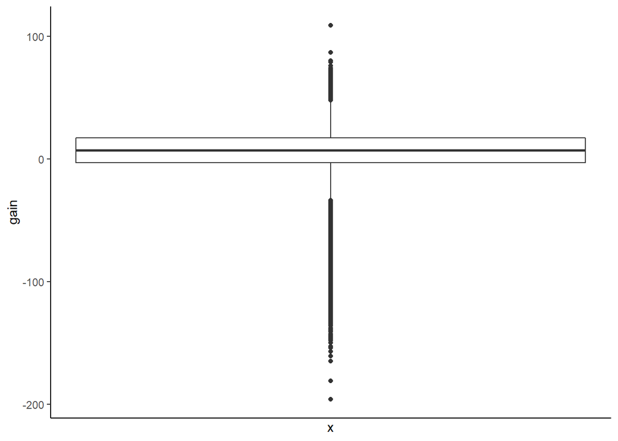

```r
flights %>%
  mutate(gain = dep_delay - arr_delay) %>%
  ggplot(aes(x=1,y=gain)) +
  geom_boxplot() +
  scale_x_continuous(breaks = NULL) +
  theme(axis.title.x = element_blank()) +
  theme_classic()
```

Most of the time the gain is a little above zero (the median is 7, meaning gain is above 0 at least 50% of the time) and between -50 and 50 minutes. There are some extreme cases however!

## Documenting software

- File creation date: 2022-06-16
- R version 4.1.3 (2022-03-10)
- `ggplot2` package version: 3.3.6
- `dplyr` package version: 1.0.9
- `nycflights13` package version: 1.0.2